# Trabajo 2: Decision Multicriterio

Marco Galliani

## Requirements

Objetivos-Tareas del Trabajo sobre Decisión Multicriterio:

- Crear un proyecto RStudio con un documento R Markdown en el que se resuelva el problema del tema elegido con todas las técnicas vistas en clase de decisión multicriterio (AHP al menos con el paquete ahp, Electre, Promethee y …). Además de la presentación y conclusiones obtenidas con los distintos métodos, también se valorará que aparezca la documentación utilizada así como material gráfico que mejore la comprensión del problema de decisión resuelto.
- La salida generada puede ser: pdf o html.

Evaluación:

- La fecha de entrega del trabajo es el viernes 1 de diciembre de 2023 a las 23:59.
- La nota del trabajo será un 10 % de la calificación en la evaluación continua de la parte de “problemas”.

## Enunciado

El problema propuesto se basa en la aplicacion de los metodos de decision a la evaluacion del mejor algoritmo de clasificacion aplicado al problema de detectar fraudes con tarjetas de credito.

En este constesto las alternativas son los diferentes algoritmos de clasificacion y los criterios son las diferentes medidas de bondad de clasificacion.

*Alternativas:*

- Support Vector Machine (SVM)
- k Nearest Neighbor
- Random Forest
- Multilayer Perceptron (MLP)

*Medidas de bondad de adjuste:*

- sensitivity (Recall)
- specificity
- precision
- f1 score
- accuracy
- AUC
- MAE

El conjunto de datos sobre que se entrenan los algoritmo es formado de una variable que indica se una fraude ha pasado o no y otras variables resultante de una ACP de las variables originales. La interpretacion de estas variables no es presente en el dataset.

## Resolucion

### 1-Exploration and preprocessing

La procedura presentada en este apartado es la misma de [(1)](https://www.kaggle.com/search)

Cargando los datos

```r
df<- read.csv("data/creditcard.csv")
```

Se consideran solo variables numericas

```r
# For while I have decided to use only the numerical variables which are the result of a PCA transformation.
df$Time<-NULL
df$Amount<-NULL
```

Separacion del conjunto de datos

```r
# train-test split, createDataPartition  create balanced splits of the data, random sampling occurs within each class
# tt will be a matrix of row position to the training data

set.seed(1512)
tt<-createDataPartition(
  y=df$Class,
  times = 1,
  p = 0.75,
  list = FALSE
)

dftrain<-df[tt,]
dftest<-df[-tt,]
```

No en balance

```r
table(dftrain$Class)
```

```
##
##      0      1
## 213229    377
```

Oversampling

```r
# here, I will apply oversampling and undersampling at the same time
# the minority class is oversampled with replacement and majority class is undersampled without replacement

dftrain_s<-ovun.sample(Class~., data=dftrain, seed=1512, method = "both", p=0.5, N= 10000)$data

table(dftrain_s$Class)
```

```
##
##    0    1
## 5016 4984
```

### 2-Modelling

Entrenamiento de los modelos considerados y evaluacion de las medidas de bondad de adjuste consideradas en el conjunto de datos de test

```r
dftrain_s$Class<-as.factor(dftrain_s$Class)
```

```r
training_classifiers <- function(classifier_name){
    # training the model
    model <- train(form = Class~.,
                   data = dftrain_s,
                   trControl = trainControl(method="cv", number=5),
                   method = classifier_name)

    # prediction on the test set
    pred <- predict(model, dftest)

    # computation of the confusion matrix
    cm <- confusionMatrix(pred, as.factor(dftest$Class), positive="1")


    # computing performance metrics
    c( sensitivity = cm[["byClass"]][["Sensitivity"]], # (sensitivity is the same as recall)
       specificity = cm[["byClass"]][["Specificity"]],
       precision = cm[["byClass"]][["Precision"]],
       f1 = cm[["byClass"]][["Precision"]],
       accuracy = cm[["overall"]][["Accuracy"]],
       AUC = ModelMetrics::auc(pred, as.factor(dftest$Class)),
       MAE = ModelMetrics::mae(pred, as.factor(dftest$Class))
    )
}
```

```r
decision_table <- list()

decision_table[["svmRadial"]] <- training_classifiers("svmRadial")
decision_table[["knn"]] <- training_classifiers("knn")
decision_table[["rf"]] <- training_classifiers("rf")
decision_table[["mlp"]] <- training_classifiers("mlp")


decision_table <- as.data.frame(decision_table)
```

### 3-Analisis de Decision Multicriterio

```r
criteria <- list()

criteria$names <- rownames(decision_table)
alternatives <- colnames(decision_table)

knitr::kable(decision_table, digits = 2)
```

|  | svmRadial | knn | rf | mlp |
| --- | --- | --- | --- | --- |
| sensitivity | 0.90 | 0.91 | 0.87 | 0.91 |
| specificity | 0.99 | 0.97 | 1.00 | 0.98 |
| precision | 0.12 | 0.05 | 0.68 | 0.07 |
| f1 | 0.12 | 0.05 | 0.68 | 0.07 |
| accuracy | 0.99 | 0.97 | 1.00 | 0.98 |
| AUC | 0.56 | 0.52 | 0.84 | 0.54 |
| MAE | 0.01 | 0.03 | 0.00 | 0.02 |

```r
# minimizar MAE
decision_table_mod <- decision_table
decision_table_mod["MAE", ] <- -decision_table["MAE", ]
```

#### (1) Extracting the weights

Para construir la tabla de comparacion de importancia relativa entre los criterios usamos la siguiente escala

- 1: Igual importancia para dos criterios
- 3: Debil importancia de uno sobre otro
- 5: Importancia esencial o fuerte de uno sobre otro
- 7: Importancia demonstrada de un criterio sobre otro
- 9: Importancia absoluta de uno sobre otro
- 2,4,6,8: valores intermedios

Medidas de bondad de adjuste ([enlace](https://en.wikipedia.org/wiki/Precision_and_recall))

- sensitivity (Recall)
- specificity
- precision
- f1 score
- accuracy
- AUC
- MAE

*Motivaciones:* En esta aplicacion tiene sentido asumir que la medida recall sea mas importante de la medida de precision. De hecho quiseriamos que la frauda sean detectada en el numero mayor posible y no nos interesa si tenemos algunas falsa detectiones de fraudas.

La medida de accuracy no es buena en el caso de datos no distribuidos equamente.

```r
table_criteria <-  multicriterio.crea.matrizvaloraciones_mej(
    c(9, 9, 4, 6, 1/4, 7,
      1/4, 1/5, 1/2, 1/9, 1/4,
      1/4, 2, 1/9, 2,
      6, 1/7, 4,
      1/9, 1/3,
      9),
    numalternativas = length(criteria$names),
    v.nombres.alternativas = criteria$names
    )
table_criteria
```

```
##             sensitivity specificity precision        f1 accuracy       AUC
## sensitivity   1.0000000           9      9.00 4.0000000      6.0 0.2500000
## specificity   0.1111111           1      0.25 0.2000000      0.5 0.1111111
## precision     0.1111111           4      1.00 0.2500000      2.0 0.1111111
## f1            0.2500000           5      4.00 1.0000000      6.0 0.1428571
## accuracy      0.1666667           2      0.50 0.1666667      1.0 0.1111111
## AUC           4.0000000           9      9.00 7.0000000      9.0 1.0000000
## MAE           0.1428571           4      0.50 0.2500000      3.0 0.1111111
##                   MAE
## sensitivity 7.0000000
## specificity 0.2500000
## precision   2.0000000
## f1          4.0000000
## accuracy    0.3333333
## AUC         9.0000000
## MAE         1.0000000
```

```r
extraction_AHP <- multicriterio.metodoAHP.variante1.autovectormayorautovalor(table_criteria)

extraction_AHP$consistencia
```

```
## [1] "Consistencia aceptable"
```

```r
extraction_AHP$RI.coef.inconsistencia
```

```
## [1] 0.09903228
```

```r
criteria$weights <- extraction_AHP$valoraciones.ahp
criteria$weights
```

```
## sensitivity specificity   precision          f1    accuracy         AUC
##  0.25859897  0.02128947  0.05143110  0.11917938  0.02940233  0.47316824
##         MAE
##  0.04693050
```

#### (2) Applying decision methods

##### -> Promethee

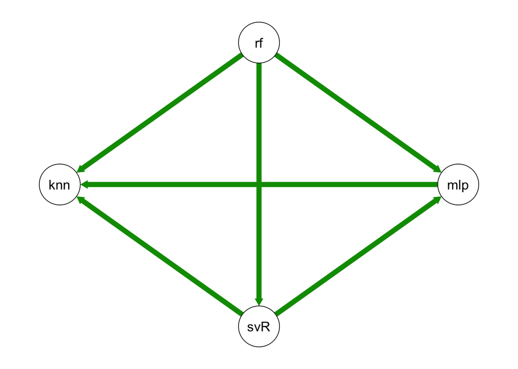

```r
tab.fpref = matrix(c(
    # func, qi, pi, si
    1, 0,0,0,
    1, 0,0,0,
    1, 0,0,0,
    1, 0,0,0,
    1, 0,0,0,
    1, 0,0,0,
    1, 0,0,0
    ),
    nrow = 7,
    ncol = 4,
    byrow = T
)

promethee_I <- multicriterio.metodo.promethee_i(t(as.matrix(decision_table_mod)),
                                 pesos.criterios = criteria$weights,
                                 tab.fpref = tab.fpref
                                 )

promethee_II <- multicriterio.metodo.promethee_ii(t(as.matrix(decision_table_mod)),
                                 pesos.criterios = criteria$weights,
                                 tab.fpref = tab.fpref
                                 )

qgraph::qgraph(promethee_I$tablarelacionsupera)
qgraph::qgraph(promethee_II$tablarelacionsupera)
```

[output not shown]

##### -> AHP

Para respectar el axioma de homogeneidad usamos uno de los metodos de homogeneizacion antes de aplicar AHP

```r
metodo_AHP <- multicriterio.metodoAHP.pesosglobales_entabla(
    criteria$weights,
    t(multicriterio.homogeneizacion.promethee(t(as.matrix(decision_table_mod)),
                                              v.delta.min = c(0,0,0,0,0,0,-1),
                                              v.delta.max = c(1,1,1,1,1,1,0)))
)
```

Ordenamiento:

```r
sort(metodo_AHP[,"Ponderadores Globales"], decreasing = T)
```

```
##         rf  svmRadial        mlp        knn
##  0.7033069 -0.1752128 -0.2415894 -0.2865047
```

##### -> Electre

Primera iteracion

```r
ELECTRE <- multicriterio.metodoELECTRE_I(
    t(as.matrix(decision_table_mod)),
    pesos.criterios = criteria$weights,
    nivel.concordancia.minimo.alpha = 0.8,
    no.se.compensan = c(Inf, Inf, Inf, Inf, Inf, Inf, Inf),
    que.alternativas = T)

ELECTRE$nucleo_aprox
```

```
## svmRadial        rf       mlp
##         1         3         4
```

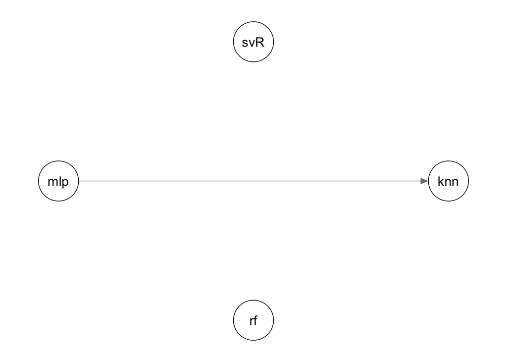

```r
qgraph::qgraph(ELECTRE$relacion.dominante)
```

Segunda iteracion

```r
ELECTRE <- multicriterio.metodoELECTRE_I(
    t(as.matrix(decision_table_mod)),
    pesos.criterios = criteria$weights,
    nivel.concordancia.minimo.alpha = 0.7,
    no.se.compensan = c(Inf, Inf, Inf, Inf, Inf, Inf, Inf),
    que.alternativas = c( T, F, T, T))

ELECTRE$nucleo_aprox
```

```
## rf
##  3
```

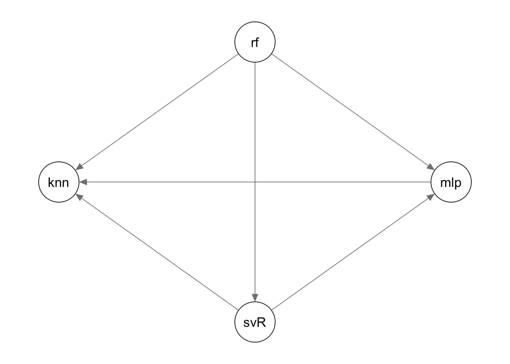

```r
qgraph::qgraph(ELECTRE$relacion.dominante)
```

##### -> Topsis

```r
criteria$objective_sym <- c("+", "+", "+", "+", "+", "+", "-")

topsis <- topsis(t(decision_table),
       criteria$weights,
       criteria$objective_sym)

topsis_ranking <- map_chr(1:length(alternatives), function(index){
    alternatives[which(topsis$rank == index)]
})
```

Ordenamiento

```r
topsis_ranking
```

```
## [1] "rf"        "svmRadial" "mlp"       "knn"
```

## Conclusion

El ordenamento obtenido siempre es lo mismo. El mejor metodo en este caso es el metodo “Random Forest”

## References

1. kaggle notebook: “MCDM for algorithm selection” por el usuario Golden, se puede encontrar [aqui](https://www.kaggle.com/search)
2. Kou G, Lu Y, Peng Y, Shi Y. Evaluation of classification algorithms using MCDM and rank correlation. Int J Info Tech Dec Mak. 2012;11:197–225. [aqui](https://www.worldscientific.com/doi/pdf/10.1142/S0219622012500095)